# Intro to GIS in Public Health

Carrie Fahey

June 12, 2017

# Definitions

- **Spatial Data**
  - Data that have a spatial component, i.e. are connected to a place.
- **GIS: Geographic Information System**
  - Platform to collect, analyze, and integrate spatial data.
- **GPS: Global Positioning System**
  - A satellite-based navigation system used to determine the ground position of an object in GPS coordinates (latitude and longitude).
- **Geocoding**
  - The process of converting a postal address into latitude and longitude.

# Applications of GIS in Public Health

- **Exposure assessment**
  - Air pollution, flood risk, distance to health facility, etc.
- **Disease surveillance**
  - Spatial transmission patterns, case clustering
- **Health care service planning**
  - Resource allocation and coordination
- **Impact assessment**
  - Assessing the impact of interventions across areas

## Historical Example: John Snow’s Cholera Map (1854)

[figure not shown]

John Snow’s 1854 map of London cholera cases. *Image Source*: https://www.physics.smu.edu/pseudo/DrSnow/

[figure not shown]

*Animation Source*: https://public.tableau.com/en-us/s/gallery/mapping-1854-cholera-outbreak

### Limitations of John Snow’s Map

1. Population density not considered.
2. Privacy and confidentiality not protected.

## Modern Example: Mapping Zimbabwe PMTCT Data

[Targeting elimination of mother-to-child HIV transmission efforts using geospatial analysis of mother-to-child HIV transmission in Zimbabwe](http://journals.lww.com/aidsonline/Abstract/2016/07170/Targeting_elimination_of_mother_to_child_HIV.17.aspx)

by Sandra I. McCoy, Carolyn Fahey, Raluca Buzdugan, Angela Mushavi, Agnes Mahomva, Nancy S. Padian and Frances M. Cowan

### Background

We assessed Zimbabwe’s progress toward elimination of mother-to-child HIV transmission (MTCT) under Option A.

### Methods

We analyzed 2012 and 2014 cross-sectional serosurvey data from mother-infant pairs residing in the same 157 health facility catchment areas randomly sampled from five provinces. Eligible women were at least 16 years and mothers/caregivers of infants born 9-18 months prior. We aggregated individual-level questionnaire and HIV serostatus within catchment areas or district to estimate MTCT and the number of HIV-infected infants; these data were mapped using facility global positioning system coordinates.

### Results

- A weighted population of 8800 and 10 404 mother-infant pairs was included from 2012 and 2014, respectively.
- In 2014, MTCT among HIV-exposed infants was 6.7% (95% confidence interval: 5.2, 8.6), not significantly different from 2012 (8.8%, 95% confidence interval: 6.9, 11.1, P¼0.13).
- From 2012 to 2014, self-reported antiretroviral therapy or prophylaxis among HIV-infected women increased from 59 to 65% (P¼0.05), as did self-reported infant antiretroviral prophylaxis (63 vs. 67%, P¼0.08).
- In 2014, 65 (41%), 55 (35%), and 37 (24%) catchment areas had the same, lower, and higher MTCT rate as in 2012, respectively.
- MTCT in 2014 varied by catchment areas (median=0%, mean=4.9%, interquartile range=0-10%) as did the estimated number of HIV-infected infants (median=0, mean=1.1, interquartile range=0-1.0).
- Also in 2014, 106 (68%) catchment areas had MTCT=0%.
- Geovisualization revealed clustering of catchment areas where both MTCT and the estimated number of HIV-infected infants were relatively high.

### Maps

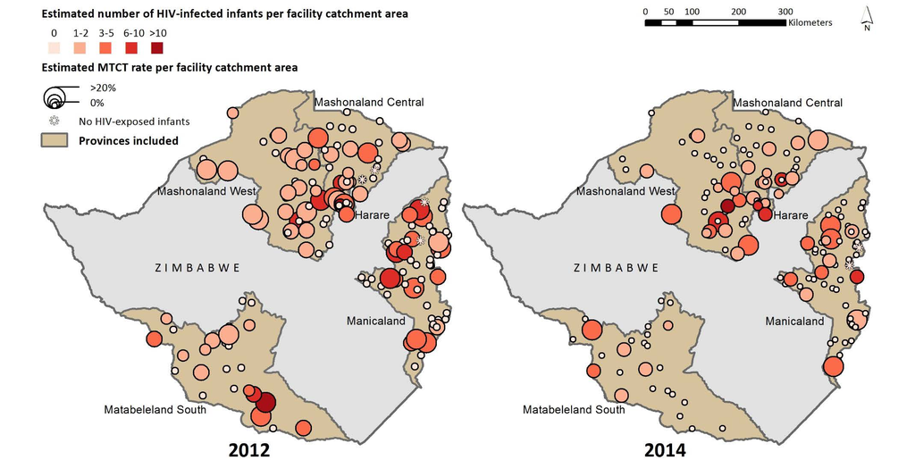

Estimated number of HIV-infected infants and MTCT rate in 156 selected health facility catchment areas in five provinces in Zimbabwe, 2012 and 2014. Data from pregnant women and their infants were linked to health facility catchment area; their inclusion in a particular area does not necessarily imply that the mother-infant pair received care at that facility, or received care at all.

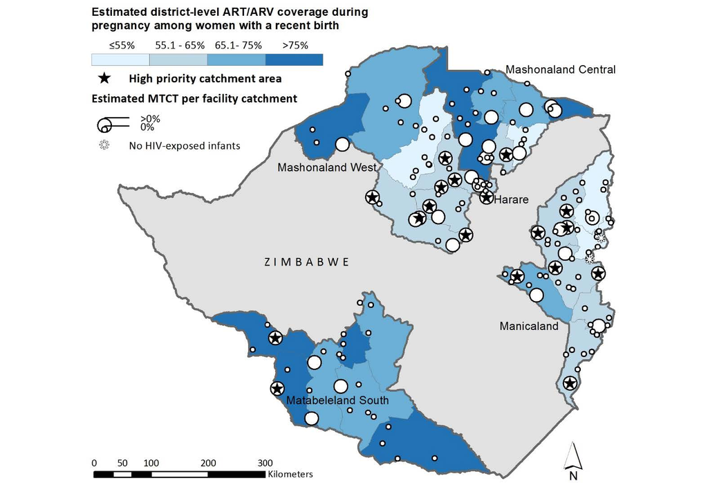

Estimated number of HIV-infected infants and MTCT rate in 156 selected health facility catchment areas in five provinces in Zimbabwe, 2014. High priority catchment areas (as determined with our algorithm) are labeled with a star. Maternal ART/antiretroviral coverage in the background.

### Conclusion

Although MTCT is declining in Zimbabwe, geospatial analysis indicates facility-level variability. Catchment areas with high MTCT rates and a high burden of HIV-infected infants should be the highest priority for service intensification.

# Spatial Data

Spatial data are multi-dimensional. This makes spatial data somewhat unique, requiring different methods for managing, analyzing, and visualizing data.

### Types of spatial data

- **Raster**
  - Images (satellite imagery, etc.)
- **Vector**
  - Points (health facilities, etc.
  - Lines (roads, rivers, etc.)
  - Polygons (provinces, districts, etc.)

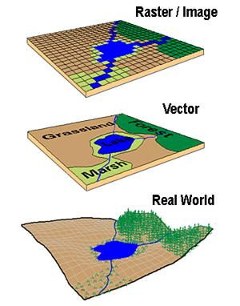

*Image Source*: http://planet.botany.uwc.ac.za/nisl/gis/web_page/page_15.htm

### Software for working with spatial data

There are many different software options for working with spatial data. Here are just a few common ones:

- **ArcGIS**
  - The most commonly used GIS software, used as a platform for spatial data analysis, management, and visualization.
- **QGIS**
  - A free, open source GIS software.
- **R**
  - A free, widely used, open source statistical software, which can be used for spatial data analysis and visualization.

### Where to find spatial data

**The Internet!**

- Google “Zimbabwe raster”
  - [Zimbabwe Landcover 2009](http://geonode.wfp.org/layers/geonode:zwe_phy_landcover_meris_2009)
- Google “Zimbabwe shapefile”
  - [Zimbabwe Health Institutions](https://data.humdata.org/dataset/zimbabwe-health)